# Preprocessing of time dependent data

### STL decomposition

STL is an acronym for “Seasonal and Trend decomposition using Loess”, while loess (locally weighted regression and scatterplot smoothing) is a method for estimating nonlinear relationships.

We start our analysis with the creation of a ts object. This is done by the ts() function. We make use of the first and last function from the xts package and the year and month function from the lubridate package to extract the starting year/month (start) and the ending year/month (end) combinations of the data set programmatically.

```r
start <- c(year(xts::first(df)), month(xts::first(df)))
start
```

```
## [1] 2002    1
```

```r
end <- c(year(xts::last(df)), month(xts::last(df)))
end
```

```
## [1] 2024   12
```

```r
df_ts <- ts(data = as.vector(coredata(df)),
          start = start,
          end = end, frequency = 12)
```

In R the stl() function performs decomposition of a time series into seasonal, trend and irregular components using Loess. The function requires the s.window argument, which is either the character string “periodic” or the span (in lags), an odd number, of the loess window for seasonal extraction. The default value is 7. Type help(stl) into your console for more information on the stl() function. Let us apply the stl() function and plot the result with the convenient autoplot() function.

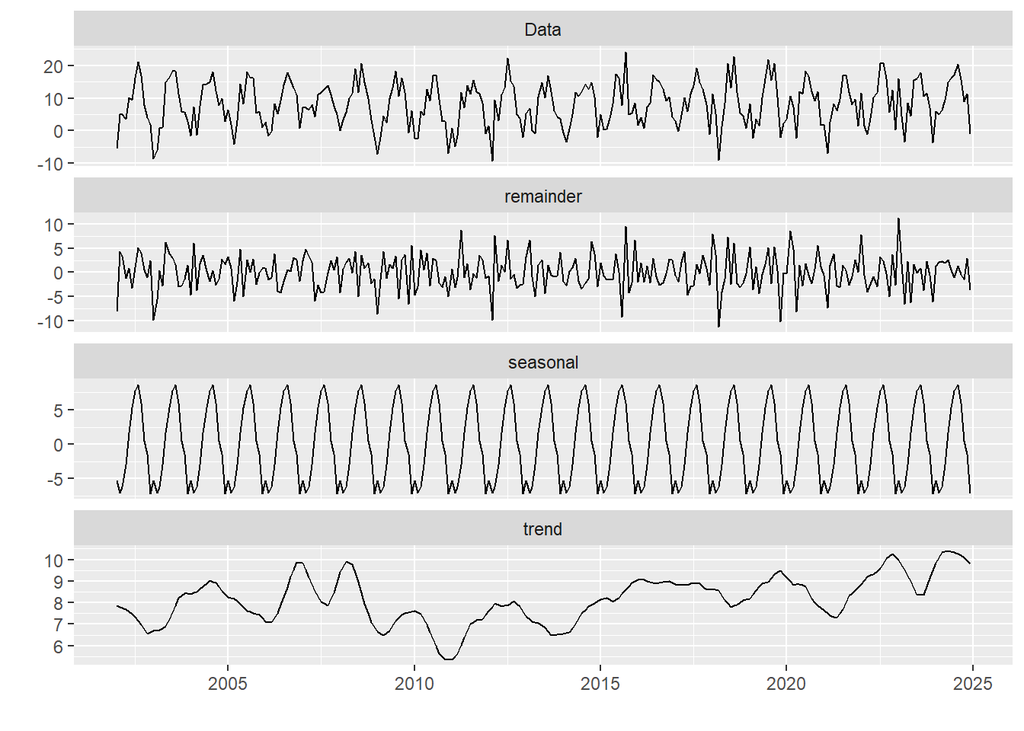

```r
# set up stl function
fit <- stl(df_ts,s.window = "periodic")

# plot stl
autoplot(fit)
```

The plot shows four panels. In the uppermost panel, we see the raw temperature data, where we might not observe a clear positive trend during the period from 2002 to 2024. In the subsequent plot, we can see the remainder, the seasonal component and the trend component. The temperature increase is more evident now. The remainder appears quite noisy and lacks a distinct pattern, which suggests that the seasonal decomposition has effectively extracted the trend and seasonal components.

The decomposed parts of the time series are stored in the stl object and can be accessed using the $time.series notation. Let’s save them in a DataFrame.

```r
# Extract the components
trend_component <- fit$time.series[, "trend"]
seasonal_component <- fit$time.series[, "seasonal"]
remainder_component <- fit$time.series[, "remainder"]

date_format <- format(as.Date(time(df_ts)), "%Y-%m")

# Combine components into a DataFrame
decomposed_df <- data.frame(
  Date = date_format,
  Trend = trend_component,
  Seasonal = seasonal_component,
  Remainder = remainder_component,
  Observed = df_ts
)
head(decomposed_df)
```

```
##      Date    Trend  Seasonal  Remainder Observed
## 1 2002-01 7.849945 -5.246057 -8.1038876     -5.5
## 2 2002-02 7.807487 -7.075073  4.2675861      5.0
## 3 2002-03 7.765029 -6.212781  3.4477518      5.0
## 4 2002-04 7.679661 -2.929591 -1.2500699      3.5
## 5 2002-05 7.594293  1.718815  0.7868911     10.1
## 6 2002-06 7.465419  5.342768 -3.3081878      9.5
```

We can also do the same for a shorter time period of the data set:

```r
df_ts2020 <- ts(data = as.vector(coredata(df)),
          start = c(2020, 1),
          end = c(2024, 12), frequency = 12)
```

### Detrending

A very typical use case is to apply STL for detrending a time series. We detrend our data set by subtracting the trend from the original data.

$$y_t^* = y_t- T_t$$

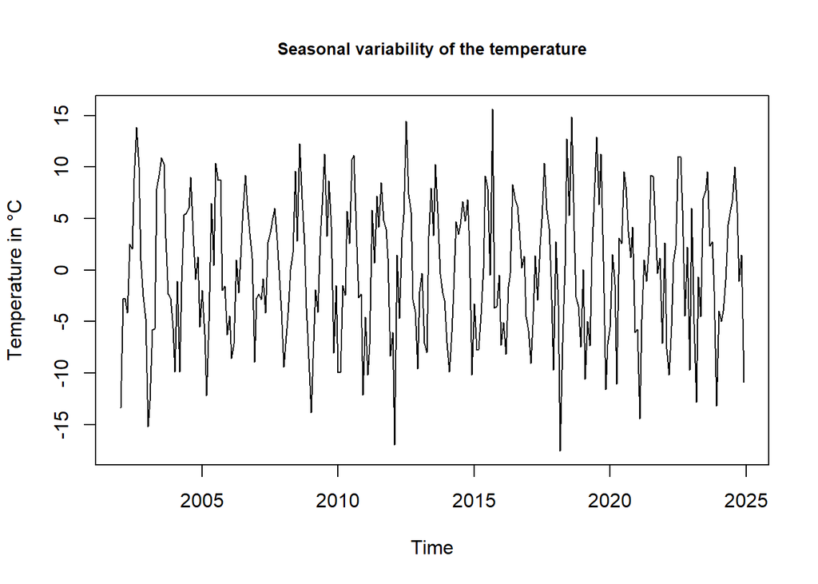

```r
detrended <- decomposed_df$Observed - decomposed_df$Trend
plot.ts(detrended,
  ylab = "Temperature in °C",
  main = "Seasonal variability of the temperature",
  cex.main = 0.85
)
```

### Normality check of the residuals

Next, we check if the residuals are normally distributed to assure that the additive model was the right choice.

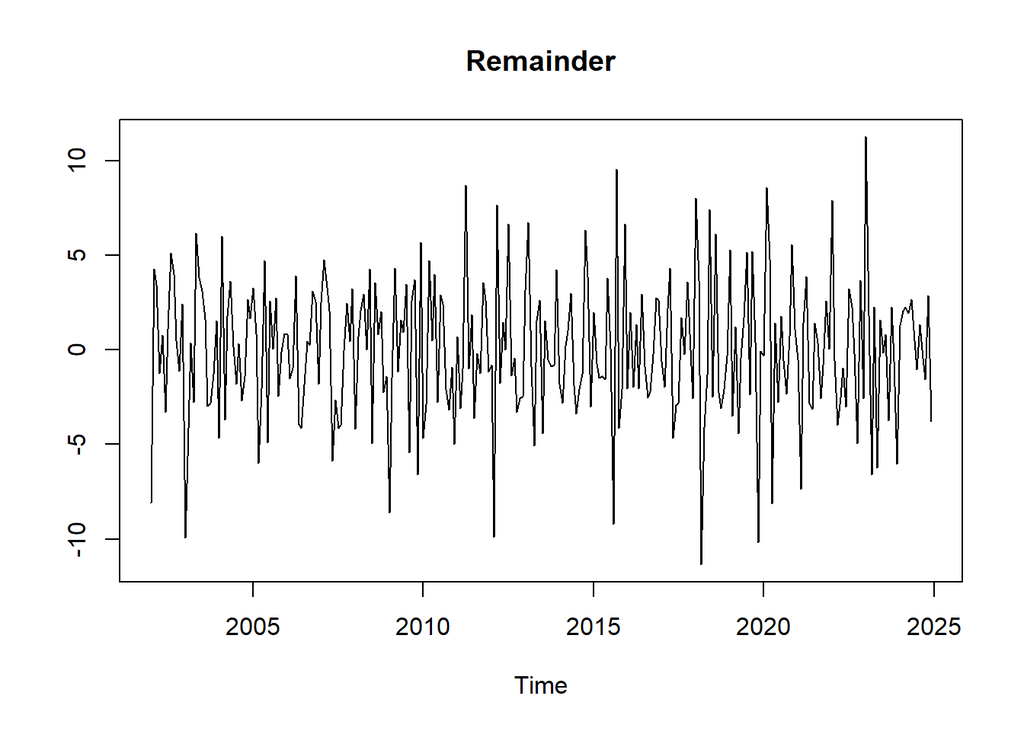

```r
plot(decomposed_df$Remainder, main = "Remainder", ylab = "")
```

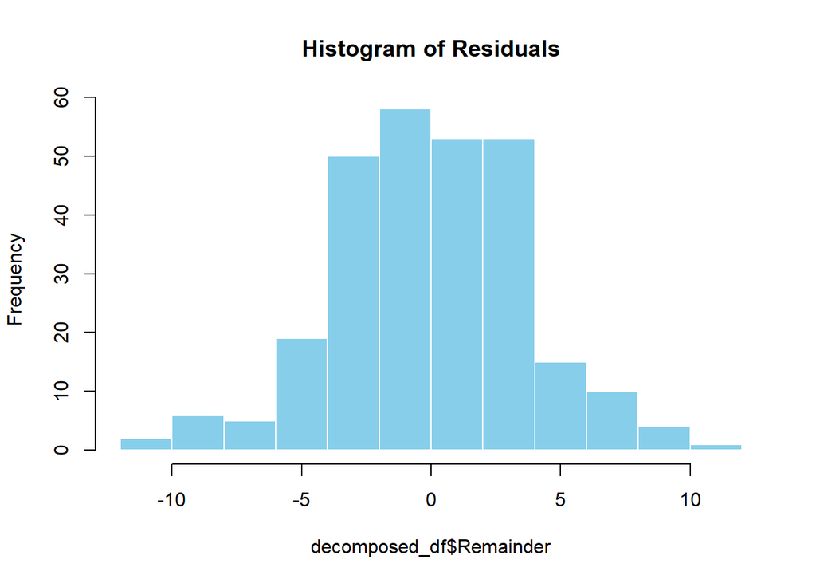

```r
# Plot Temperature
hist(decomposed_df$Remainder,
     main = "Histogram of Residuals",
     col = "skyblue",
     border = "white")
```

The residuals seem fairly well normally distributed. However, let us apply a [Shapiro–Wilk test](https://en.wikipedia.org/wiki/Shapiro%E2%80%93Wilk_test) and check for normality.

```r
shapiro.test(decomposed_df$Remainder)
```

```
##
##  Shapiro-Wilk normality test
##
## data:  decomposed_df$Remainder
## W = 0.99386, p-value = 0.3249
```

The large p-value supports our believe, that the seasonal decomposition did a good job in extracting the trend and the seasonal components, as the residual seems to be just noise.

## Exercises of Time Series Data Analysis

> **Exercise 1**  
> Use the dataset “Tagesmittel_Dahmem.csv”, select one variable, preprocess the data, and perform an STL decomposition.

> **Alternative Exercise**  
> Consider the time period 2004-2024, create a new dataframe that contains the data for this time period and perform a STL.

# Time series Part II - ARIMA (Autoregressive Integrated Moving Average) Models

Autoregressive (AR) models and moving average (MA) models are two different approaches to forecasting time series data. ARIMA - *Auto-Regressive Integrated Moving Average* - models combine these ideas.

Forecasting is a subfield of machine learning that uses the past behavior of a time series to predict one or more of its future values. Consider the number of visitors at a beer garden: if past data show that the more drinks are sold as the weather gets warmer, you would expect to order drinks for next week than for this week. How much more you order should depend on how this week’s sales differ from last week’s sales. This illustrates a central idea of time series forecasting: we cannot make meaningful predictions about the future without information about the past, so historical data are crucial for ARIMA and for all forecasting and time series analysis methods.

We start with white noise and autocorrelation, the random walk and the moving average.

## White noise and autocorrelation

If the random variables which make up $y_t$ are uncorrelated, have means 0 and variance $\sigma^2$, then $y_t$ is stationary with an autocovariance function of

$$\gamma_w(s,t) = \text{cov}(w_s, w_t)=
\begin{cases}
\sigma^2_w & s=t \\
0 & \text{otherwise.}
\end{cases}$$

This type of series is referred to as [**white noise**](https://en.wikipedia.org/wiki/White_noise). The designation *white* originates from the analogy with white light and indicates that all possible periodic oscillations are present with equal strength ([Shumway and Stoffer 2011](http://www.springer.com/gp/book/9783319524511)).

A particularly useful white noise series is *Gaussian white noise*, wherein the $w_t$ are independent and identically distributed (*iid*) normal random variables, with mean 0 and variance $\sigma^2$.

$$w_t \sim \text{iid } N(0, \sigma^2_w)$$

We may easily generate a Gaussian white noise in R using the `rnorm()` function.

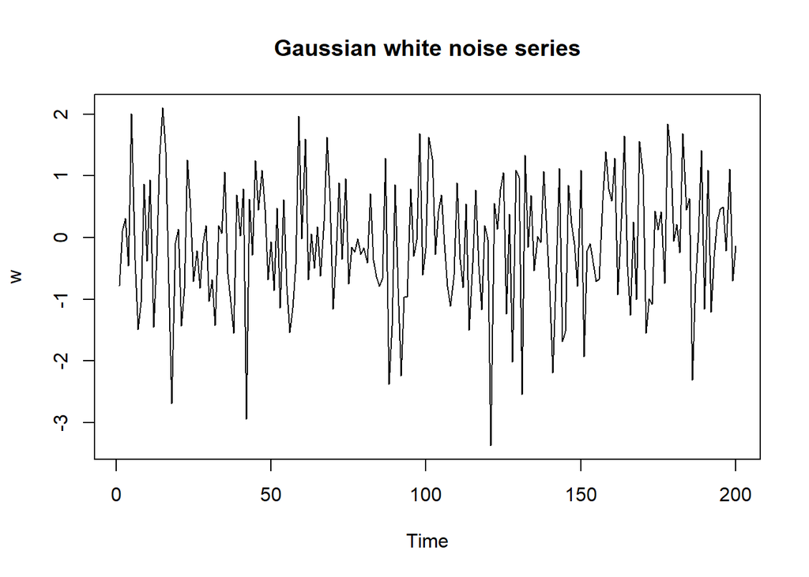

```r
set_seed <- 133 # set seed for reproducibility
w <- rnorm(n = 200, mean = 0, sd = 1)
plot.ts(w, main = "Gaussian white noise series")
```

Let us plot the correlogram by using the `acf()` function. This time, however, for a more convenient visualization, we embed the `acf()` function into the `autoplot()` function provided by the `ggfortify` package.

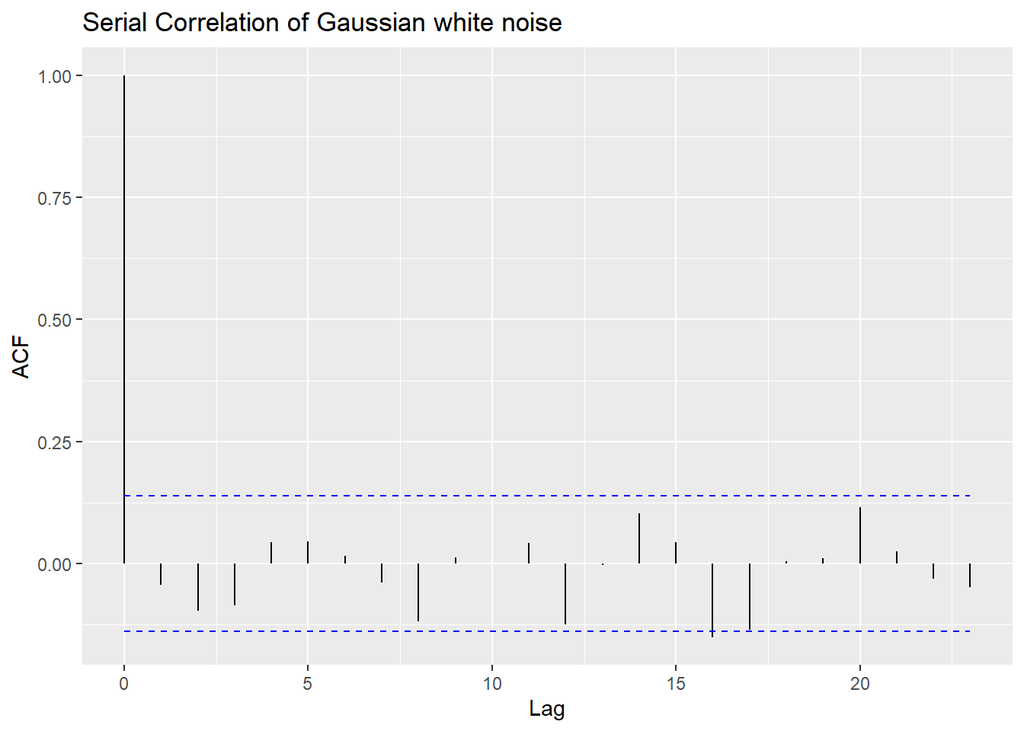

```r
library(ggfortify)
autoplot(acf(w, plot = FALSE)) +
  ggtitle("Serial Correlation of Gaussian white noise")
```

## Random walk model

A model for analyzing a series, which is the sum of a deterministic *trend* series and a stationary *noise* series, is the so called **[random walk](https://en.wikipedia.org/wiki/Random_walk) with drift model**, given by

$$y_t = \delta+y_{t-1}+w_t,$$

for $t = 1, 2,...$, with initial condition $y_0 = 0$, where $w_t$ is white noise. The constant $\delta$ is called the drift, and if $\delta = 0$, then it is simply called *random walk*.

The equation from above may be rewritten as

$$y_t = \delta t + \sum_{j=1}^t
w_j\text{,}$$

for $t = 1,2,...$.

If $\delta = 0$, the value of the time series at time $t$ is equal to the value of the series at time $t-1$ plus a completely random movement determined by $w_t$.

$$\Delta y_t = y_t-y_{t-1} =
w_t$$

The $w_{t}$ values can be interpreted as independent “shocks” which perturb the current state $y_t$ in the amount of $w_{t}$ to produce a new state $y_{t+1}$.

The graph below shows a random walk and a random walk with drift ($\delta = 0.25$) generated with R.

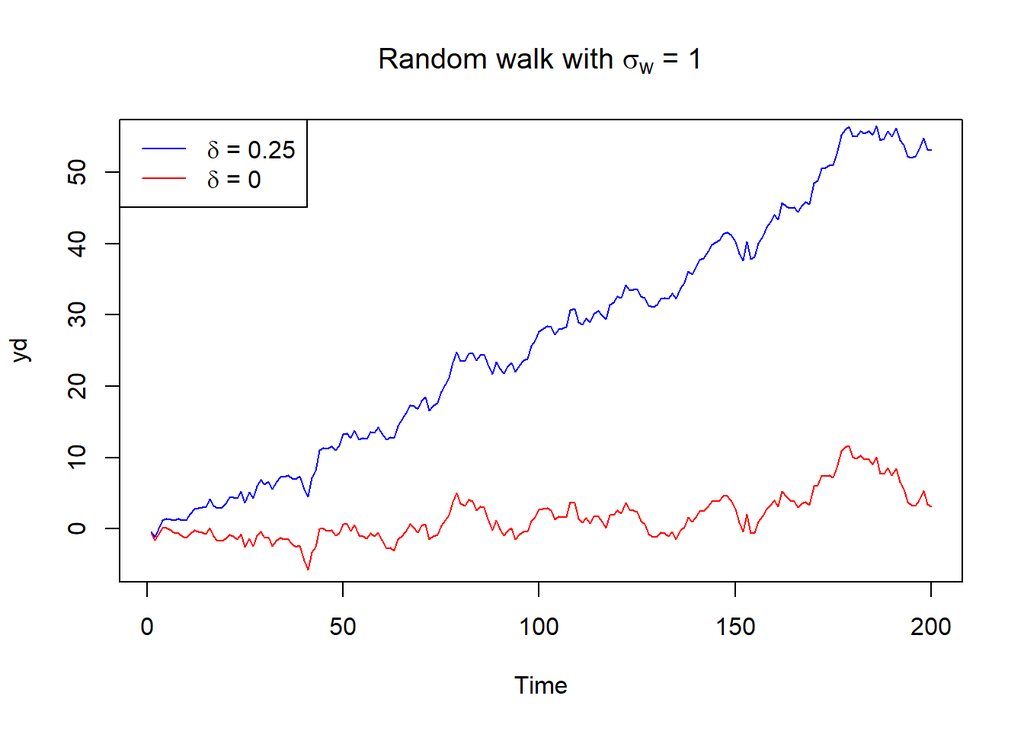

```r
set.seed(250)

## random walk
w <- rnorm(n = 200, mean = 0, sd = 1)
y <- cumsum(w)

## random walk with drift
wd <- w + .25
yd <- cumsum(wd)

## plotting
plot.ts(yd,
  ylim = c(-5, 55),
  main = expression(paste("Random walk with " * sigma[w] * " = 1")),
  col = "blue"
)

lines(y, col = "red")

legend("topleft",
  legend = c(
    expression(paste(delta * " = 0.25")),
    expression(paste(delta * " = 0"))
  ),
  col = c("blue", "red"),
  lty = 1
)
```

The autocorrelation function of this model type shows typically a very slow decay.

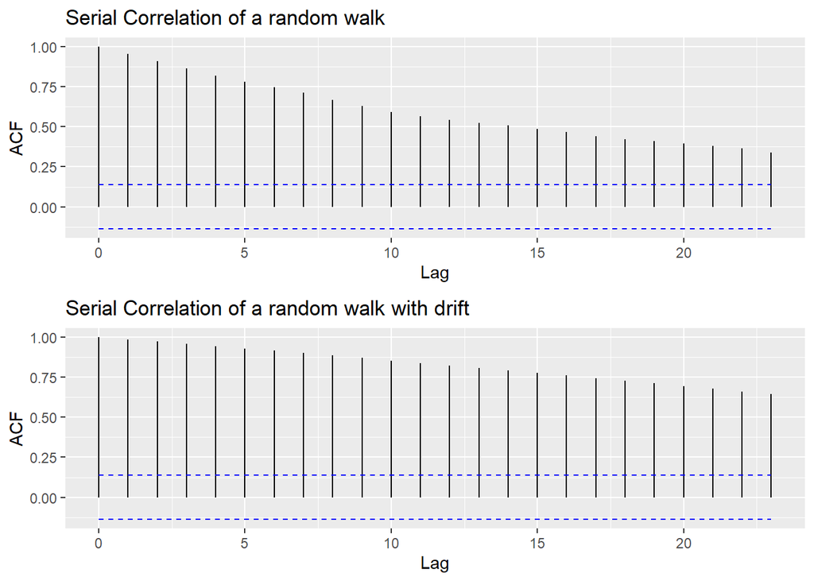

```r
library(ggfortify)
library(gridExtra)

p1 <- autoplot(acf(y, plot = FALSE)) +
  ggtitle("Serial Correlation of a random walk")

p2 <- autoplot(acf(yd, plot = FALSE)) +
  ggtitle("Serial Correlation of a random walk with drift")
grid.arrange(p1, p2, ncol = 1)
```

## Moving average model

The moving average process of order $q$ is denoted MA$(q)$ and defined by

$$y_t =
w_t+\theta_1w_{t-1}+...+\theta_qw_{t-q},$$
which can be rewritten as

$$y_t =
\sum_{j=0}^q\theta_jw_{t-j},$$

where $\theta_0 =1$, $\theta_1, \theta_2, ..., \theta_q$ are fixed constants, and $w_t$ denotes a random variable with mean $0$ and variance $\sigma^2$. In the MA model the current value of the series is a weighted sum of past white noise terms. Think of the white noise series as being stochastically uncorrelated information which appears at each time step, and which is combined with other information to provide the observation at $y_t$. Hence, moving average models are useful for modeling series that are affected by a variety of unpredictable events where the effect of these events have an immediate effect as well as possible long-term effects.

The moving average process is a stationary process with serial correlation zero at lags greater than $q$.

$$\gamma(k) =
\begin{cases}
0, & \vert k\vert > q \\
\sigma^2\sum_{j=0}^{q-\vert k\vert}\theta_j\theta_{j+k} & \vert
k\vert \le q
\end{cases}$$

In R, we can generate a moving average series by applying the `filter()` function on a white noise series.

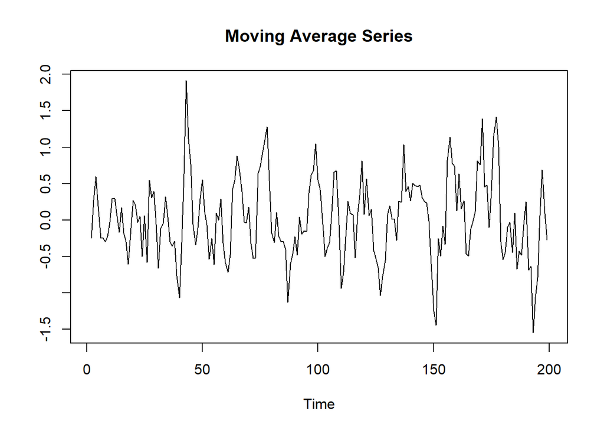

```r
set.seed(250)

## white noise series
w <- rnorm(n = 200, mean = 0, sd = 1)

## moving average
y_ma <- stats::filter(w, rep(1 / 3, 3))
plot.ts(y_ma, main = "Moving Average Series", ylab = "")
```

Another, very convenient way to simulate moving average processes in R is to use the `arima.sim()` function.

We generate two MA(1) series of the form

$$y_t =
w_t+\theta_1w_{t-1}\text{,}$$

where once $\theta_1 = 0.6$ and the other time $\theta_1 = -0.6$.

```r
ma1_1 <- arima.sim(list(order = c(0, 0, 1), ma = 0.6), n = 100)
ma1_2 <- arima.sim(list(order = c(0, 0, 1), ma = -0.6), n = 100)
```

We plot the two series using the `autolplot()` function.

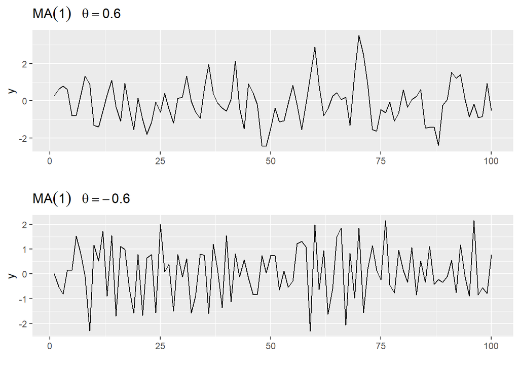

```r
library(ggfortify)
library(gridExtra)

p1 <- autoplot(ma1_1,
  ylab = "y",
  main = (expression(MA(1) ~ ~ ~ theta == 0.6))
)

p2 <- autoplot(ma1_2,
  ylab = "y",
  main = (expression(MA(1) ~ ~ ~ theta == -0.6))
)

grid.arrange(p1, p2, ncol = 1)
```

For $\theta = 0.6$, $y_t$ and $y_{t-1}$ are positively correlated, and for $\theta = -0.6$, $y_t$ and $y_{t-1}$ are negatively correlated. This correlational structure can be shown by plotting the correlogram.

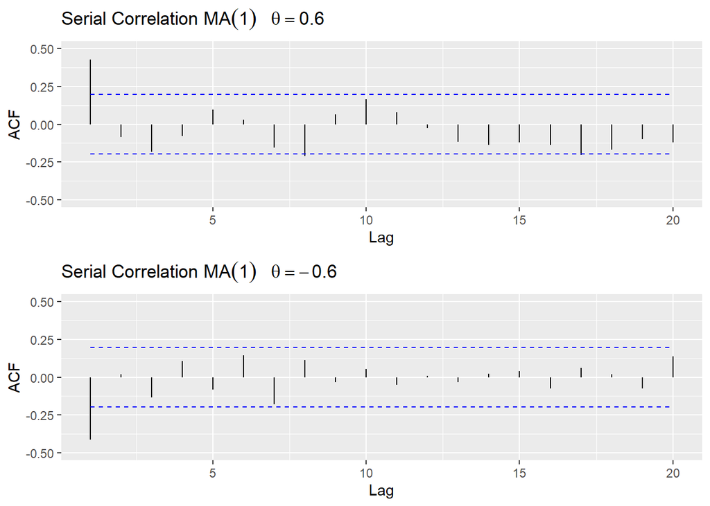

```r
p1 <- autoplot(acf(ma1_1, plot = FALSE)) +
  ggtitle(expression("Serial Correlation " * MA(1) ~ ~ ~ theta == 0.6)) +
  xlim(1, 20) +
  ylim(-0.5, 0.5)

p2 <- autoplot(acf(ma1_2, plot = FALSE)) +
  ggtitle(expression("Serial Correlation " * MA(1) ~ ~ ~ theta == -0.6)) +
  xlim(1, 20) +
  ylim(-0.5, 0.5)

grid.arrange(p1, p2, ncol = 1)
```

A typical feature of the autocorrelation function of a MA process is that it drops to nearly zero beyond $q$.

## Autoregressive models

The autoregressive process of order $p$ is denoted AR($p$), and defined by

$$y_t =
\phi_1y_{t-1}+\phi_2y_{t-2}...+\phi_py_{t-p}+w_t\text{,}$$

which can be rewritten as

$$y_t = \sum_{i=1}^p\phi_iy_{t-i}+
w_t\text{,}$$

where $\phi_1, \phi_2,..., \phi_p$ are fixed constants and $w_t$ is a random variable with mean 0 and variance $\sigma^2$.

If the mean, $\mu$, of $y_t$ is not zero, we replace $y_t$ by $y_t-\mu$:

$$y_t-\mu =
\sum_{i=1}^p\phi_i(y_{t-i}-\mu)+ w_t$$

Autoregressive processes have a natural interpretation as the next value observed is a slight perturbation of the most recent observations or, in other words, the current value of the series is linearly dependent upon its previous values, with some random error. This model is called an *autoregressive* (AR) model since $y_t$ is regressed on itself.

#### Example AR(1)

The special case of $p = 1$, the first-order process, is also known as [Markov process](https://en.wikipedia.org/wiki/Markov_chain).

We generate two AR(1) series of the form

$y_t = \phi_1 y_{t-1}+w_t\text{,}$

where once $\phi_1 = 0.6$ and the other time $\phi_1 = -0.6$.

```r
set.seed(250)

ar1_1 <- arima.sim(list(order = c(1, 0, 0), ar = 0.6), n = 100)
ar1_2 <- arima.sim(list(order = c(1, 0, 0), ar = -0.6), n = 100)
```

We plot the two series using the `autolplot()` function.

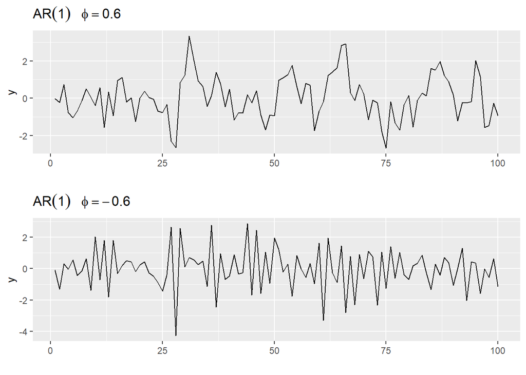

```r
library(ggfortify)
library(gridExtra)

p1 <- autoplot(ar1_1,
  ylab = "y",
  main = (expression(AR(1) ~ ~ ~ phi == 0.6))
)

p2 <- autoplot(ar1_2,
  ylab = "y",
  main = (expression(AR(1) ~ ~ ~ phi == -0.6))
)

grid.arrange(p1, p2, ncol = 1)
```

For an AR(1) model the current value $y_t$ of the time series is a function of the last preceding value of the series. We may review the correlational structure by plotting the correlogram.

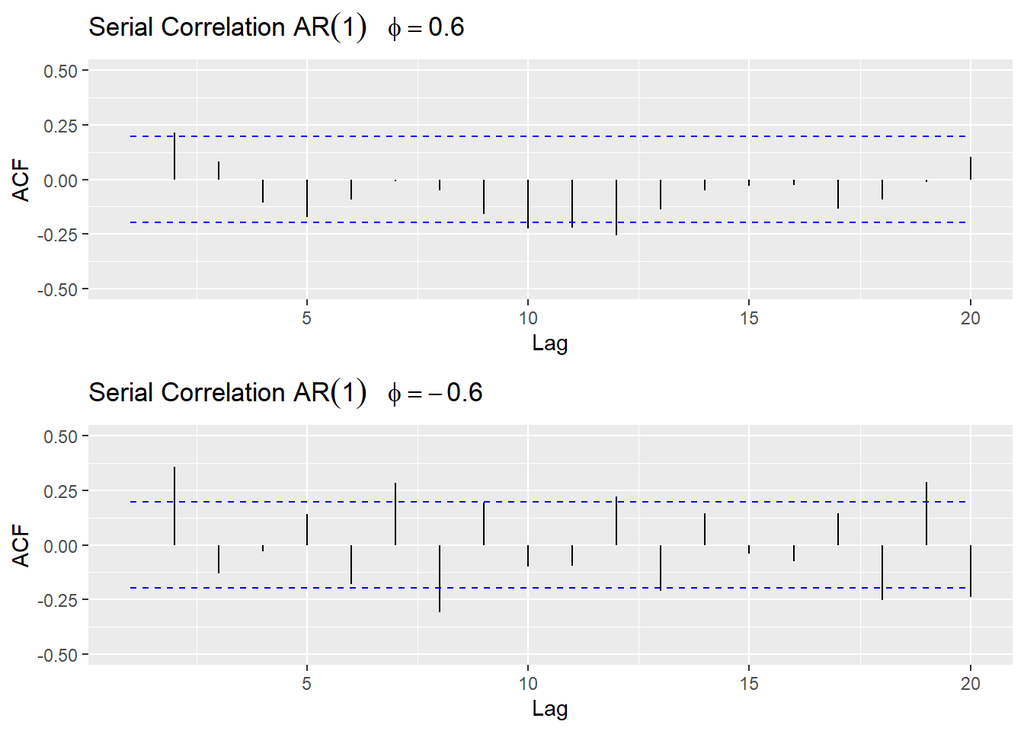

```r
p1 <- autoplot(acf(ar1_1, plot = FALSE)) +
  ggtitle(expression("Serial Correlation " * AR(1) ~ ~ ~ phi == 0.6)) +
  xlim(1, 20) +
  ylim(-0.5, 0.5)

p2 <- autoplot(acf(ar1_2, plot = FALSE)) +
  ggtitle(expression("Serial Correlation " * AR(1) ~ ~ ~ phi == -0.6)) +
  xlim(1, 20) +
  ylim(-0.5, 0.5)

grid.arrange(p1, p2, ncol = 1)
```

The autocovariance function for the AR series decays exponentially (for $\phi >0$), with a possible sinusoidal variation superimposed (for $\phi <0$). Thus, the correlation drops off faster the greater the value of $k$.

#### Example AR(2)

For an AR(2) model, which can be written as

$y_t = \phi_1 y_{t-1}+\phi_2 y_{t-2}+w_t\text{,}$

the current value $y_t$ of the time series is a function of the last two preceding values of the series.

Let us generate four different AR(2) series to review their autocorrelational structures.

- AR(2) model I: $\phi_1 = 0.5$ and $\phi_2 = 0.3$
- AR(2) model II: $\phi_1 = -0.5$ and $\phi_2 = 0.3$
- AR(2) model III: $\phi_1 = 1$ and $\phi_2 = -0.5$
- AR(2) model IV: $\phi_1 = -0.5$ and $\phi_2 = -0.3$.

We make use of the `arima.sim()` function to generate these four AR(2) models and plot the correlogram by using the `autoplot()` function in combination with the `acf()` function.

```r
ar2_I <- arima.sim(list(
  order = c(2, 0, 0),
  ar = c(0.5, 0.3)
), n = 100)

ar2_II <- arima.sim(list(
  order = c(2, 0, 0),
  ar = c(-0.5, 0.3)
), n = 100)

ar2_III <- arima.sim(list(
  order = c(2, 0, 0),
  ar = c(1, -0.5)
), n = 100)

ar2_IV <- arima.sim(list(
  order = c(2, 0, 0),
  ar = c(-0.5, -0.3)
), n = 100)
```

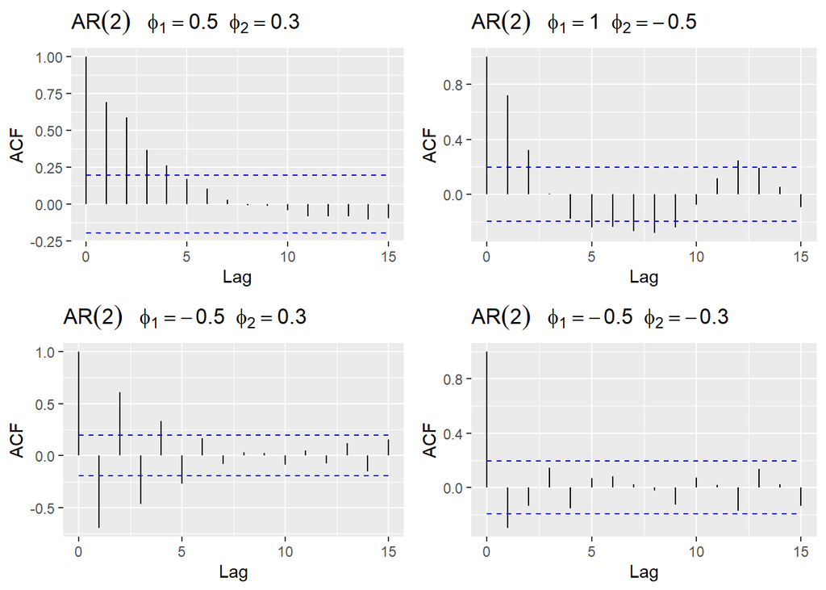

```r
p1 <- autoplot(acf(ar2_I, plot = FALSE, lag.max = 15)) +
  ggtitle(expression(AR(2) ~ ~ ~ phi[1] == 0.5 * ~ ~ phi[2] == 0.3))

p2 <- autoplot(acf(ar2_II, plot = FALSE, lag.max = 15)) +
  ggtitle(expression(AR(2) ~ ~ ~ phi[1] == -0.5 * ~ ~ phi[2] == 0.3))

p3 <- autoplot(acf(ar2_III, plot = FALSE, lag.max = 15)) +
  ggtitle(expression(AR(2) ~ ~ ~ phi[1] == 1 * ~ ~ phi[2] == -0.5))

p4 <- autoplot(acf(ar2_IV, plot = FALSE, lag.max = 15)) +
  ggtitle(expression(AR(2) ~ ~ ~ phi[1] == -0.5 * ~ ~ phi[2] == -0.3))

grid.arrange(p1, p3, p2, p4, ncol = 2)
```

The autocovariance functions exhibit exponential decay, with a possible sinusoidal variation superimposed.

We can combine the autoregressive (AR($p$)) and moving average (MA($q$)) processes to form a mixed autoregressive moving average process as follows

$$y_t =
\underbrace{\phi_1y_{t-1}+...+\phi_p y_{t-p}}_{\text{AR}} +
\underbrace{\theta_iw_{t-1}+...+\theta_qw_{t-q}}_{\text{MA}}\text{,}$$
with $\phi_p \ne 0$, $\theta_q \ne 0$, and $\sigma^2_w >0$. The equation can be rewritten as

$$y_t =
\underbrace{\sum_{i=1}^p\phi_iy_{t-i}+ w_t}_{\text{AR}} +
\underbrace{\sum_{i=0}^q\theta_iw_{t-i}}_{\text{MA}}\text{.}$$

The term is called an *autoregressive-moving average series of order* ($p$, $q$), or [**ARMA($p$, $q$)**](https://en.wikipedia.org/wiki/Autoregressive%E2%80%93moving-average_model) series. If $q = 0$, the model is called an autoregressive model of order $p$, AR($p$), and if $p = 0$, the model is called a moving average model of order $q$, MA($q$). A slightly more general definition of an ARMA process incorporates a non-zero mean value $\mu$, and can be obtained by replacing $y_t$ by $y_t-\mu$ and $y_{t-i}$ by $y_{t-i}-\mu$ in the equation above.

ARMA models may be seen as a regression of the present outcome $(y_t)$ on the past outcomes $(y_{t-1}, ..., y_{t-p})$ with correlated errors.

#### The Partial Autocorrelation Function

The autocorrelation function of an MA series cuts of sharply whereas those for AR and ARMA series exhibit exponential decay (with possible sinusoidal behavior superimposed). This makes it difficult to distinguish between an ARMA series and a purely AR series by plotting only its autocorrelation function. Hence, the *partial autocorrelation function* (PACF) is used since it behaves like the ACF of MA models, but for AR models.

The partial autocorrelation function (PACF) of a stationary process, $y_t$, denoted $\phi_{kk}$, for $k=1,2,...,$ is

$$\phi_{kk} = \text{cor}(y_k-\hat y_k,
y_0-\hat y_0), \quad k \ge 2\text{,}$$
where $\hat y_k$ is the regression of $y_k$ on $\{y_1, y_2,...,y_{k-1}\}$. The PACF, $\phi_{kk}$, is the correlation between $y_{t+k}$ and $y_t$, but with the linear dependence of every value between them, namely $\{y_{t+1},y_{t+2},...,y_{t+k-1} \}$, removed. In other words, the partial autocorrelation is the correlation between $y_s$ and $y_t$ without the linear effect of everything in the middle. The computation of PACF is done recursively via the [*Durbin-Levinson algorithm*](https://en.wikipedia.org/wiki/Levinson_recursion).

The PACF for MA models behaves much like the ACF for AR models. Also, the PACF for AR models behaves much like the ACF for MA models. The behavior of ACF and PACF for ARMA models is summarized in ([Shumway and Stoffer 2011](http://www.springer.com/gp/book/9783319524511) and [Wei 2006](https://astro.temple.edu/~wwei/book.html)).

$$\begin{array}{l|lll}
& \text{AR}(p) & \text{MA}(q) & \text{ARMA}(p,q) \\
\hline
\text{ACF} & \text{Tails off}^\text{1} & \text{Cuts off after
lag }q & \text{Tails off after lag (}q-p\text{)} \\
\text{PACF} & \text{Cuts off after lag }p & \text{Tails
off}^\text{1} & \text{Tails off after lag (}p-q\text{)}\\
\hline
\end{array}$$
*$^\text{1}$Tails off as exponential decay or damped sine wave.*

If the ACF exhibits slow decay and the PACF cuts off sharply after lag $p$, we would identify the series as AR$(p)$. If the PACF shows slow decay and the ACF show a sharp cutoff after lag $q$, we would identify the series as being MA($q$). If both the ACF and PACF show slow decay we would identify the series as being ARMA($p,q$).

#### Simulation of an ARMA process

In this section we simulate AR, MA and ARMA processes and review their autocorrelational structures. Therefore we apply the `arima.sim()` function and build three different models, each with a mean of 50:

AR(2) model: $y_t = 50 + 1.5(y_{t-1}-50)-0.75(y_{t-2}-50)+ w_t$

MA(1) model: $y_t = 50 + w_t-0.7w_{t-1}$

ARMA(1,1) model: $y_t = 50+ 0.9(y_{t-1}-50)+ w_t-0.4w_{t-1}$

```r
set.seed(250)

arma_20 <- arima.sim(list(
  order = c(2, 0, 0),
  ar = c(1.5, -0.75)
),
n = 200
) + 50

arma_01 <- arima.sim(list(
  order = c(0, 0, 1),
  ma = -0.7
),
n = 200
) + 50

arma_11 <- arima.sim(list(
  order = c(1, 0, 1),
  ar = 0.9,
  ma = -0.4
),
n = 200
) + 50
```

In the next step we plot each model for 200 time steps.

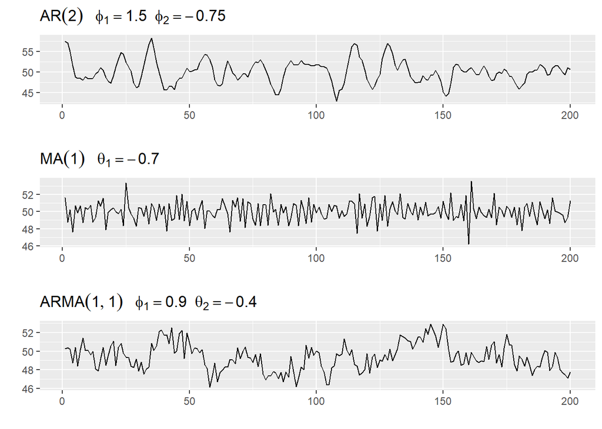

```r
library(ggfortify)
library(gridExtra)

p1 <- autoplot(arma_20) +
  ggtitle(expression(AR(2) ~ ~ ~ phi[1] == 1.5 * ~ ~ phi[2] == -0.75))

p2 <- autoplot(arma_01) +
  ggtitle(expression(MA(1) ~ ~ ~ theta[1] == -0.7))

p3 <- autoplot(arma_11) +
  ggtitle(expression(ARMA(1, 1) ~ ~ ~ phi[1] == 0.9 * ~ ~ theta[2] == -0.4))

grid.arrange(p1, p2, p3, ncol = 1)
```

Now we review the correlational structure for each of the three models.

**AR(2) process**

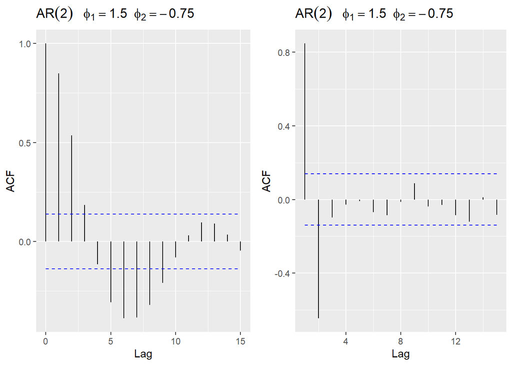

```r
## ACF
p1 <- autoplot(acf(arma_20,
  plot = FALSE,
  lag.max = 15
)) +
  ggtitle(expression(AR(2) ~ ~ ~ phi[1] == 1.5 * ~ ~ phi[2] == -0.75))

## PACF
p2 <- autoplot(acf(arma_20,
  plot = FALSE,
  lag.max = 15,
  type = "partial"
)) +
  ggtitle(expression(AR(2) ~ ~ ~ phi[1] == 1.5 * ~ ~ phi[2] == -0.75))

grid.arrange(p1, p2, ncol = 2)
```

**MA(1) process**

Based on the table from above, we expect the ACF to cut off after lag $q=1$ and the PACF to tail off.

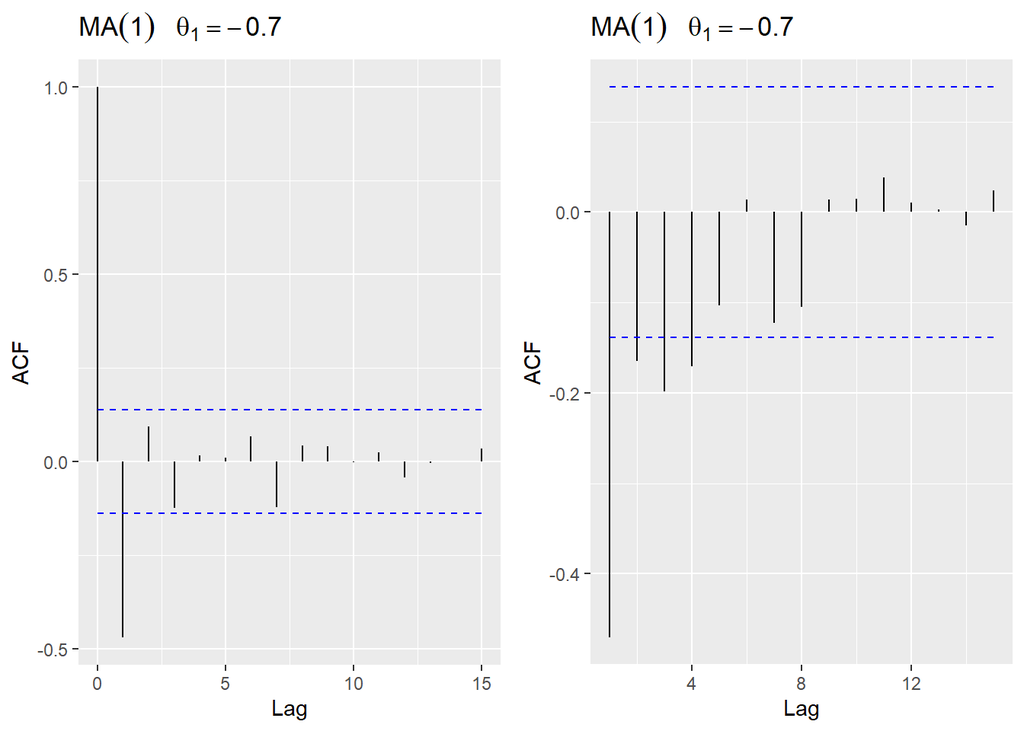

```r
## ACF
p1 <- autoplot(acf(arma_01,
  plot = FALSE,
  lag.max = 15
)) +
  ggtitle(expression(MA(1) ~ ~ ~ theta[1] == -0.7))

## PACF
p2 <- autoplot(acf(arma_01,
  plot = FALSE,
  lag.max = 15,
  type = "partial"
)) +
  ggtitle(expression(MA(1) ~ ~ ~ theta[1] == -0.7))
grid.arrange(p1, p2, ncol = 2)
```

**ARMA(1,1) process**

Based on the table from above, we expect the ACF and the PACF to tail off.

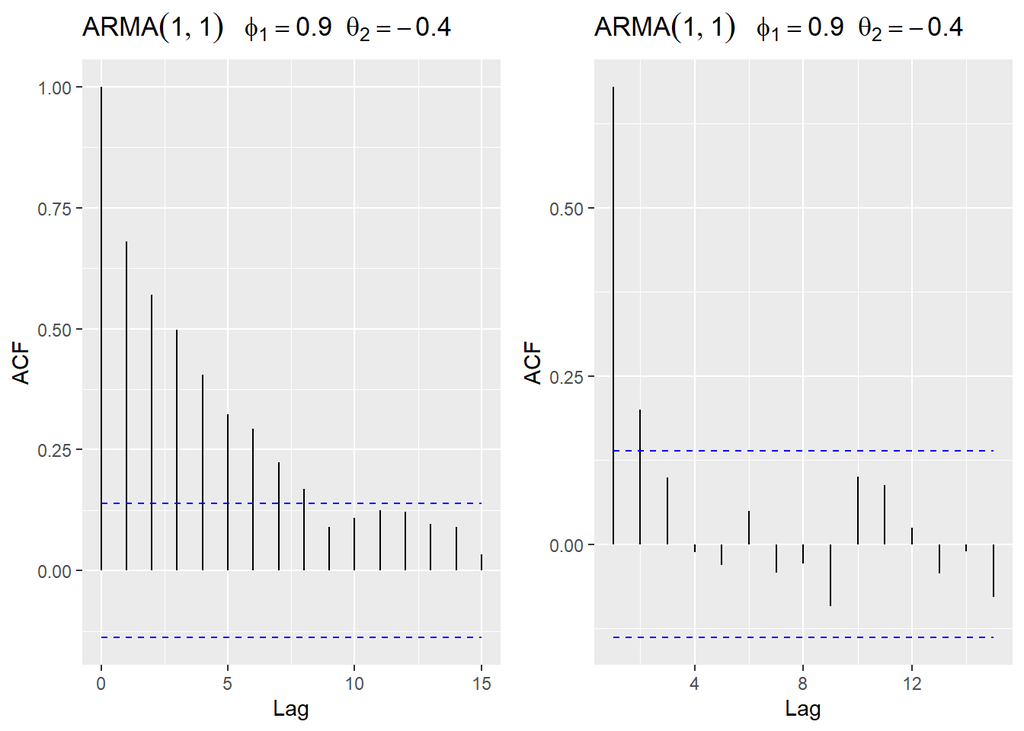

```r
## ACF
p1 <- autoplot(acf(arma_11,
  plot = FALSE,
  lag.max = 15
)) +
  ggtitle(expression(ARMA(1, 1) ~ ~ ~ phi[1] == 0.9 * ~ ~ theta[2] == -0.4))

## PACF
p2 <- autoplot(acf(arma_11,
  plot = FALSE,
  lag.max = 15,
  type = "partial"
)) +
  ggtitle(expression(ARMA(1, 1) ~ ~ ~ phi[1] == 0.9 * ~ ~ theta[2] == -0.4))

grid.arrange(p1, p2, ncol = 2)
```

## ARIMA

The [**autoregressive integrated moving average model**](https://en.wikipedia.org/wiki/Autoregressive_integrated_moving_average), or ARIMA model, is a broadening of the class of ARMA models in order to include differencing. The word *integrated* is due to the fact that the stationary model is fitted based on the differenced data.

$$y'_t = \phi_1y'_{t-1}+...+\phi_p
y'_{t-p}+\theta_iw_{t-1}+...+\theta_qw_{t-q},$$
where $y"_t$ is the differenced series.

An ARIMA process of order $p$ for the AR part, order $q$ for the MA part and differences $d$ is denoted as ARIMA($p, d, q$), where

$p-$ order of the autoregressive part,  
$d-$ degree of first differencing involved and  
$q-$ order of the moving average part.

The basic idea is that if differencing the data at some order $d$ produces an ARMA process, then the original process is said to be ARIMA. Often, a single difference will suffice to yield a stationary series.

Many of the models we have already discussed are special cases of the ARIMA model.

$$\begin{array}{ll}
\hline
\text{White noise} & \text{ARIMA(0,0,0)} \\
\text{Random walk} & \text{ARIMA(0,1,0) with no constant}\\
\text{Random walk with drift} & \text{ARIMA(0,1,0) with a constant}
\\
\text{Autoregression} & \text{ARIMA(}p\text{,0,0)} \\
\text{Moving average} & \text{ARIMA(0,0,}q\text{)}
\end{array}$$

[Hyndman and Athanasopoulos (2013)](https://www.otexts.org/fpp/) outline the general approach for fitting an ARIMA model to a set of time series data.

1. Plot the data. Identify any unusual observations.
2. If necessary, transform the data (e.g. [log transformations](https://www.geo.fu-berlin.de/en/v/soga-r/Advances-statistics/Feature-scales/Non_Linear_transformations/index.html), [logistic transformation](https://www.geo.fu-berlin.de/en/v/soga-r/Advances-statistics/Feature-scales/transformations_for_double_contraint_intervals/index.html), etc.) to stabilize the variance.
3. If the data is non-stationary: take first differences of the data until the data are stationary.
4. Examine the ACF/PACF: Which AR($p$), MA($q$), ARMA($p, q$) or ARIMA($p, d, q$) model is appropriate?
5. Choose a model and then use the [$AICc$](https://en.wikipedia.org/wiki/Akaike_information_criterion#AICc) as a criterion to search for a better model. (cf. [Intro of AIC in MLR](https://www.geo.fu-berlin.de/en/v/soga-r/Advances-statistics/Multivariate-approaches/Multiple-linear-regression/Advanced-example/Regression-modelling-and-model-selection/index.html))
6. Check the residuals from the chosen model by plotting the ACF of the residuals, and doing a [*portmanteau test*](https://en.wikipedia.org/wiki/Portmanteau_test) of the residuals. If they do not look like white noise, try a modified model.
7. Once the residuals look like white noise, calculate forecasts.

#### The data

For the sake of demonstration we fit a model to the *global annual temperature anomalies* (`t_global`) provided by the [Berkeley Earth Surface Temperature Study](http://berkeleyearth.org/summary-of-findings/). Temperatures are given in Celsius and are reported as anomalies relative to the period January 1951 to December 1980 average. Revisit the section on *data sets used* to remind yourself how we downloaded and extracted the data set of interest.

```r
load(url("https://userpage.fu-berlin.de/soga/data/r-data/Earth_Surface_Temperature.RData"))

str(t_global)
```

```
## An xts object on Jan 1750 / Jun 2022 containing:
##   Data:    double [3270, 2]
##   Columns: Monthly_Anomaly_Global, Monthly_Unc_Global
##   Index:   yearmon [3270] (TZ: "UTC")
```

We see that the data set consist of monthly mean temperatures.

> **Exercise**: Aggregate the data (`t_global`) to annual means using the `apply.yearly()` function.

```r
## Your code here ...
library(xts)
t_global_year <- NULL
```

```r
library(xts)
t_global_year <- apply.yearly(t_global, mean)
```

Then, we split the data set into two parts. One part, the *training set*, is the period 1850 to 2000. Based on that data set we learn the model parameters. The other part, the *test set*, is the period 2001 to 2016. This part is used to validate our model, as we compare the model forecast with the observations.

> **Exercise**: Subset the time series (`t_global_year`) to the period 1850 to 2000 as training data set and to the period 2001 to 2016 as test data set. Calculate the annual means.

```r
## Your code here...
temp_global <- NULL # period 1850 to 2000
temp_global_test <- NULL # period 2001 to 2016
```

```r
temp_global <- t_global_year["1850/2000", "Monthly_Anomaly_Global"]
```

```r
temp_global_test <- t_global_year["2001/2016", "Monthly_Anomaly_Global"]
```

```r
library(xts)
t_global <- apply.yearly(t_global, mean)
```

Let us plot the data and identify any unusual observations.

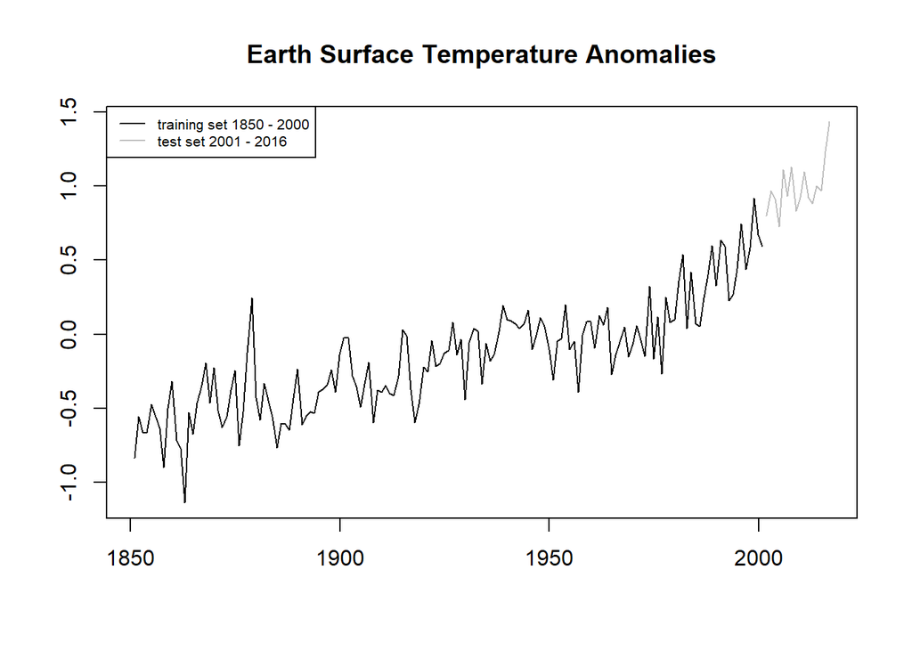

```r
plot.zoo(cbind(
  temp_global,
  temp_global_test
),
plot.type = "single",
col = c("black", "gray"),
main = "Earth Surface Temperature Anomalies",
ylab = "", xlab = ""
)
legend("topleft",
  legend = c(
    "training set 1850 - 2000",
    "test set 2001 - 2016"
  ),
  col = c("black", "gray"),
  lty = 1, cex = 0.65
)
```

It seems that there are no outliers or unusual observation in the data set.

#### Data transformation

With respect to the plot above it does not seem that the variation increases or decreases with the level of the time series. Thus, probably no transformation is required. However, just as a sanity check we apply a [*Box-Cox transformation*](https://en.wikipedia.org/wiki/Power_transform) using the `BoxCox()` function in R and plot the transformed data against the original data.

The Box-Cox transformation is defined as follows:

$$w_t =
\begin{cases}
log(y_t) & \text{if } \lambda=0 \\
(y_t^{\lambda}-1)/\lambda & \text{otherwise}
\end{cases}$$
The Box-Cox transformation depends on the parameter $\lambda$. So if $\lambda =0$ the natural logarithm is used, but if $\lambda \ne0$, a power transformation is used followed by some simple scaling. We can make use of the `BoxCox.lambda()` function, which chooses the value of $\lambda$, which minimizes the [coefficient of variation](https://en.wikipedia.org/wiki/Coefficient_of_variation).

```r
library(forecast)
lambda <- BoxCox.lambda(temp_global)
lambda
```

```
## [1] 0.9852901
```

We use the given $\lambda$ to transform our data and plot the transformed time series against the original time series.

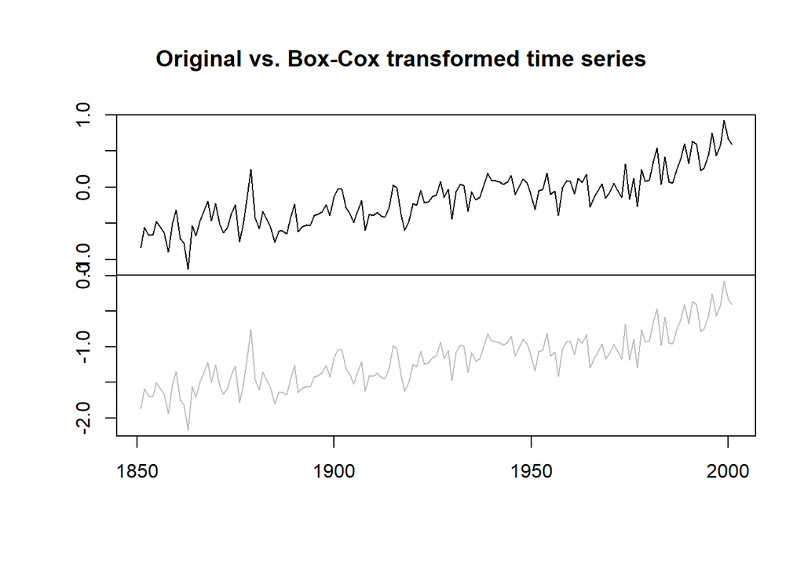

```r
# transformed time series
temp_global_BC <- BoxCox(temp_global, lambda)

plot.zoo(cbind(
  temp_global,
  temp_global_BC
),
col = c("black", "gray"),
main = "Original vs. Box-Cox transformed time series",
ylab = "", xlab = ""
)
```

The Box-Cox transformed time series (gray line) does not differ significantly from the original time series (black line). Hence, we continue our analysis with the original time series data.

#### Stationary check

Fitting an ARIMA model requires the series to be stationary, which means that the *mean*, *variance*, and *autocovariance* of the series are time invariant. Based on our domain knowledge and the visualization of the time series data we are quite sure that the temperature time series is not stationary.

As a proof of concept we apply the [**Kwiatkowski-Phillips-Schmidt-Shin (KPSS)**](https://en.wikipedia.org/wiki/KPSS_test) test. Recall, the null hypothesis in a KPSS test is that a time series is stationary.

$H_0:\text{The time series is trend-stationary.}$

$H_A:\text{The time series is not trend-stationary.}$

```r
library(tseries)
kpss.test(temp_global)
```

```
##
##  KPSS Test for Level Stationarity
##
## data:  temp_global
## KPSS Level = 2.6495, Truncation lag parameter = 4, p-value = 0.01
```

The *p*-value of the KPSS test on the original data set (`temp_global`) is $p<0.01$. Hence we reject $H_0$ in favor of $H_A$; the original time series is **not** trend-stationary.

A non-stationary series can be corrected by a simple transformation such as differencing. Recall that the difference $(\Delta y_t)$ is calculated by subtracting one period’s values from the previous period’s values. Let us apply the `diff()` function and compute the KPSS test for the differenced time series.

> **Exercise**: Difference the `temp_global` time series and apply a KPSS test on the differenced time series.

```r
## Your code here...
temp_global_diff1 <- NULL
```

```r
temp_global_diff1 <- diff(temp_global)
kpss.test(temp_global_diff1)
```

```
##
##  KPSS Test for Level Stationarity
##
## data:  temp_global_diff1
## KPSS Level = 0.024559, Truncation lag parameter = 4, p-value = 0.1
```

The *p*-value of the KPSS test on the differenced data set (`temp_global_diff1`) is $p>0.1$. Hence we would not reject $H_0$ in favor of $H_A$; the differenced time series is trend-stationary.

Let us plot the differenced data set.

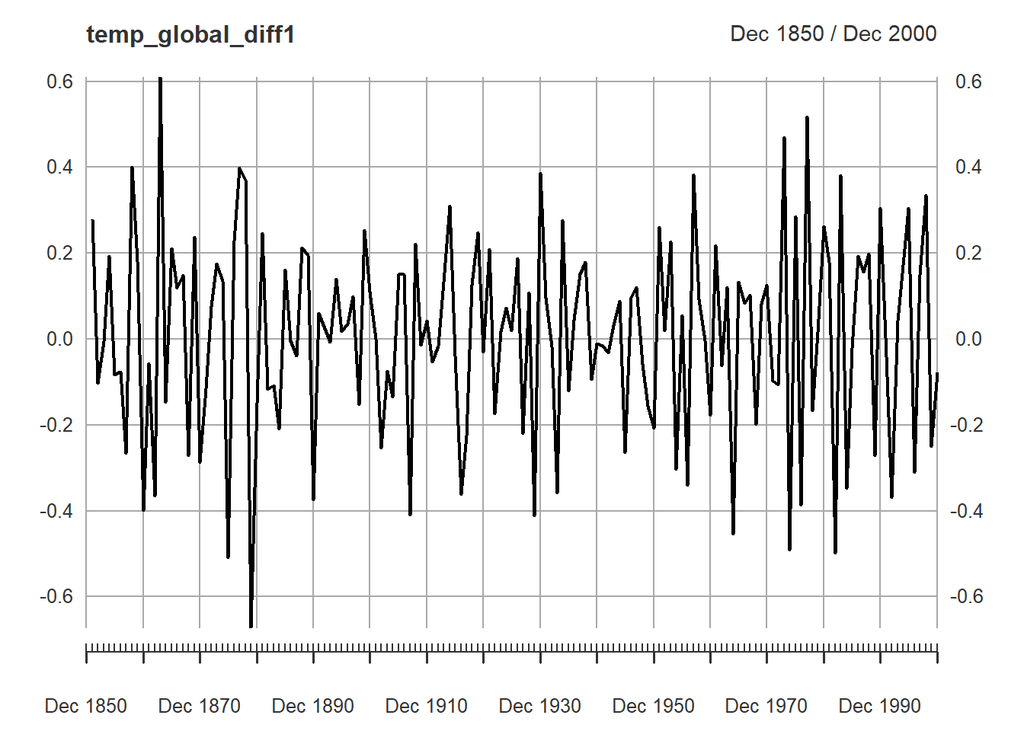

```r
plot(temp_global_diff1)
```

Nice, the trend is gone. Let us plot the autocorrelation function to review the correlational structure of the time series. This time we use the `Acf()` function from the `forecast` package. The function ships with some improvements compared to the `acf()` function from base R, but essentially these two functions are the same.

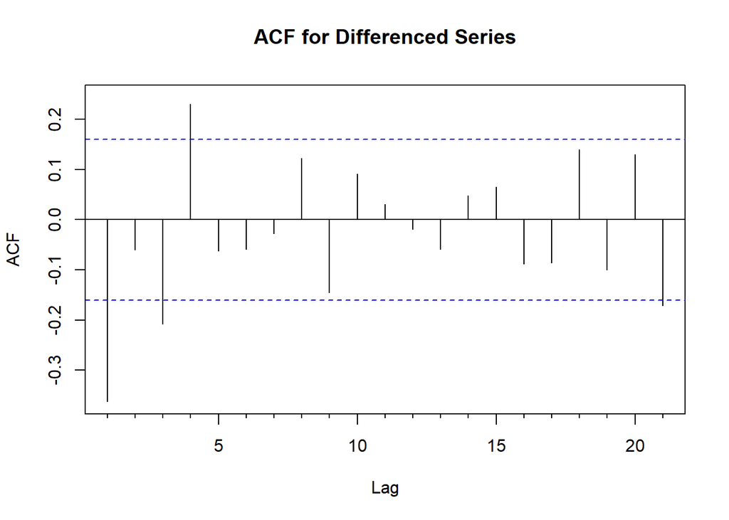

```r
Acf(temp_global_diff1,
  main = "ACF for Differenced Series"
)
```

The plot shows significant spikes at a lag of 1, 3 and 4 years.

#### Examine the ACF/PACF

In the next step, we need to identify a time series model. We need to find out which AR($p$), MA($q$), ARMA($p, q$) or ARIMA($p, d, q$) model is appropriate for our data set.

We have seen that it is possible to distinguish between AR, MA and ARMA models by the behavior of their ACF and PACF functions. If the ACF exhibits slow decay and the PACF cuts off sharply after lag $p$, we would identify the series as AR($p$). If the PACF shows slow decay and the ACF show a sharp cutoff after lag $q$, we would identify the series as being MA($q$). If both the ACF and PACF show slow decay we would identify the series as being mixed ARMA.

The theoretical behavior of ACF and PACF for ARMA models is summarized below ([Shumway and Stoffer 2011](http://www.springer.com/gp/book/9783319524511) and [Wei 2006](http://civil.colorado.edu/~balajir/CVEN6833/lectures/wwts-book.pdf)).

$$\begin{array}{l|lll}
& \text{AR}(p) & \text{MA}(q) & \text{ARMA}(p,q) \\
\hline
\text{ACF} & \text{Tails off}^\text{1} & \text{Cuts off after
lag }q & \text{Tails off after lag (}q-p\text{)} \\
\text{PACF} & \text{Cuts off after lag }p & \text{Tails
off}^\text{1} & \text{Tails off after lag (}p-q\text{)}\\
\hline
\end{array}$$
*$^\text{1}$Tails off as exponential decay or damped sine wave.*

It should be noted that the sampling variation and the correlation among the sample ACF and PACF often disguise the theoretical ACF and PACF patterns. Hence, in the initial model identification it is recommendable to concentrate on the general broad features of these sample ACF and PACF. Model improvement can be easily achieved at a later stage of diagnostic checking ([Wei 2006](https://astro.temple.edu/~wwei/book.html)).

Let us plot the ACF and PACF and try to figure out the appropriate model configuration.

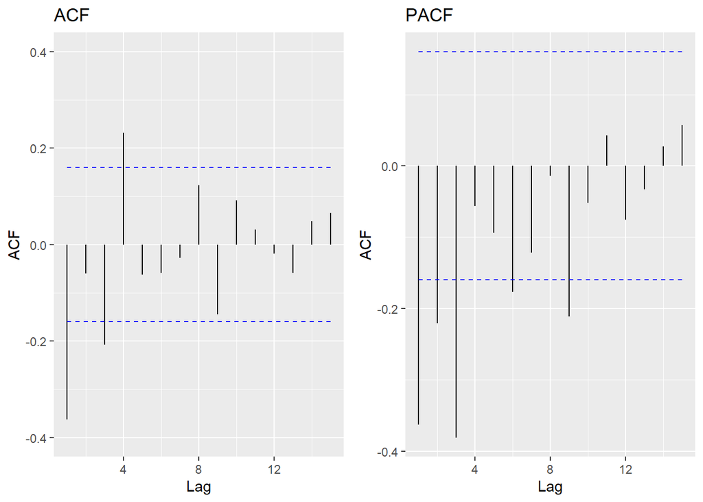

```r
library(ggfortify)
library(gridExtra)

## ACF
p1 <- autoplot(Acf(temp_global_diff1,
  plot = FALSE,
  lag.max = 15
)) + ggtitle("ACF") + xlim(1, 15) + ylim(-0.4, 0.4)

## PACF
p2 <- autoplot(Acf(temp_global_diff1,
  plot = FALSE,
  lag.max = 15,
  type = "partial"
)) + ggtitle("PACF")

grid.arrange(p1, p2, ncol = 2)
```

It seems that the ACF behaves like a damped sine wave and that the PACF cuts off after lag $p=3$ in ACF. This is suggesting an ARIMA(3, 1, 0) process.

#### Model selection

In R we fit an ARIMA model using the `Arima()` function from the `forecast` package. There is another function `arima()` in base R which also fits an ARIMA model. However, its functionality is not optimized for the usage with the `forecast` package, hence, for the purpose of this tutorial it is recommended that you use `Arima()`.

Let us fit an ARIMA(3, 1, 0) and print out the model summary. Note that we feed the original time series (`temp_global`) into our model.

```r
fit <- Arima(temp_global, order = c(3, 1, 0))
summary(fit)
```

```
## Series: temp_global
## ARIMA(3,1,0)
##
## Coefficients:
##           ar1      ar2      ar3
##       -0.5232  -0.3836  -0.3758
## s.e.   0.0758   0.0810   0.0757
##
## sigma^2 = 0.03897:  log likelihood = 31.7
## AIC=-55.4   AICc=-55.13   BIC=-43.36
##
## Training set error measures:
##                      ME      RMSE       MAE       MPE    MAPE      MASE
## Training set 0.02183716 0.1947729 0.1544819 -9.971862 127.758 0.8303968
##                     ACF1
## Training set -0.03128375
```

This is an ARIMA(3, 1, 0) model written as

$\Delta y_t = -0.5232y_{t-1}-0.3836y_{t-2}-0.3758y_{t-3}+ w_t\text{,}$

where $w_t$ is white noise with a standard deviation of $\sqrt{0.039} = 0.197$.

The corrected version of [Akaike information criterion $(AICc)$](https://en.wikipedia.org/wiki/Akaike_information_criterion#AICc) of this model is $-55.13$. This model quality metric is useful when comparing different models. In ARIMA modelling it is good practice to check some more models and compare them by comparing the $AICc$.

> **Exercise**: Fit some variations of ARIMA($p$, $d$, $q$) models including ARIMA(3, 1, 1), ARIMA(3, 1, 2), ARIMA(2, 1, 2) and compare their $AICc$.

```r
## Your code here...
```

```r
print(paste("ARIMA(3, 1, 0) - AICc: ", round(fit$aicc, 2)))
fit_test_2 <- Arima(temp_global, order = c(3, 1, 1))
print(paste("ARIMA(3, 1, 1) - AICc: ", round(fit_test_2$aicc, 2)))
fit_test_3 <- Arima(temp_global, order = c(3, 1, 2))
print(paste("ARIMA(3, 1, 2) - AICc: ", round(fit_test_3$aicc, 2)))
fit_test_4 <- Arima(temp_global, order = c(2, 1, 2))
print(paste("ARIMA(2, 1, 2) - AICc: ", round(fit_test_4$aicc, 2)))
```

[output not shown]

Of these, the ARIMA(3, 1, 2) has the smallest $AICc$ value. That is so far our best model out of these four.

The `forecast` package includes the `auto.arima()` function. The function uses a variation of the [*Hyndman and Khandakar algorithm*](https://robjhyndman.com/publications/automatic-forecasting/) which combines [unit root tests](https://en.wikipedia.org/wiki/Unit_root_test), minimization of the AICc and [maximum likelihood estimation (MLE)](https://en.wikipedia.org/wiki/Maximum_likelihood_estimation) to obtain an optimized ARIMA model. The `auto.arima()` generates a set of optimal ($p$, $d$, $q$) that optimizes model fit criteria by searching through combinations of order parameters.

```r
fit_auto <- auto.arima(temp_global, seasonal = FALSE)
summary(fit_auto)
```

```
## Series: temp_global
## ARIMA(1,1,1) with drift
##
## Coefficients:
##          ar1      ma1   drift
##       0.2311  -0.8909  0.0082
## s.e.  0.1023   0.0562  0.0024
##
## sigma^2 = 0.03752:  log likelihood = 34.31
## AIC=-60.61   AICc=-60.34   BIC=-48.57
##
## Training set error measures:
##                       ME      RMSE       MAE      MPE     MAPE      MASE
## Training set 0.001624937 0.1911154 0.1515573 4.072267 117.5581 0.8146758
##                     ACF1
## Training set 0.005120003
```

The `auto.arima()` function returns an ARIMA(1, 1,1 ) process with drift, with an $AICc$ of -60.34. This metric is slightly lower compared to our best model so far.

#### Check the residuals

Now let us check the residuals from our chosen model.

> **Exercise**: Plot the ACF of the residuals from the `fit_auto` model.

```r
## Your code here...
```

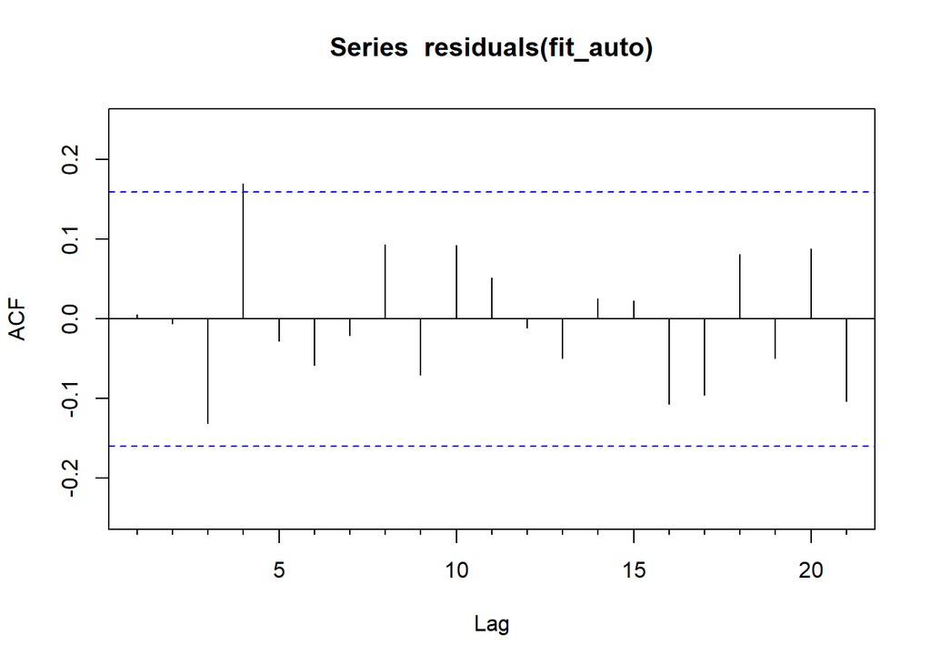

```r
Acf(residuals(fit_auto))
```

In addition to considering the ACF plot, where we are implicitly carrying out multiple hypothesis tests, each one with a small probability of giving a false positive, we may apply a more formal test for autocorrelation. A [*portmanteau test*](https://en.wikipedia.org/wiki/Portmanteau_test), from a French word describing a suitcase containing a number of items, tests a group of autocorrelations ([Hyndman and Athanasopoulos, 2013](https://www.otexts.org/fpp/)).

One such test is the [*Ljung-Box*](https://en.wikipedia.org/wiki/Ljung%E2%80%93Box_test) test based on the statistic

$$Q=T(T+2)\sum_{k=1}^h(T-k)^{-1}r^2_k\text{,}$$

where $h$ is the maximum lag being considered, $T$ is number of observations, and $r_k$ is the autocorrelation for lag $k$. If some $r_k$ values are large (positive or negative), then $Q$ will be large. If the autocorrelations did come from a white noise series, then both $Q$ would have a $\chi^2$ distribution with $(h-K)$ degrees of freedom where $K$ is the number of parameters in the model. [Hyndman and Athanasopoulos (2013)](https://www.otexts.org/fpp/) suggest using $h=10$ for non-seasonal data and $h=2m$ for seasonal data, where $m$ is the period of seasonality.

**Ljung-Box test**

$H_0: \text{The data is independently distributed.}$

$H_A: \text{The data is not independently distributed, it exhibits serial correlation.}$

```r
B_test <- Box.test(residuals(fit_auto),
  lag = 10,
  fitdf = 6,
  type = "Ljung"
)
B_test
```

```
##
##  Box-Ljung test
##
## data:  residuals(fit_auto)
## X-squared = 11.557, df = 4, p-value = 0.02097
```

The portmanteau test returns a large p-value ($P=0.021$), suggesting the residuals are white noise with $\alpha<0.01$ but also may exhibit serial correlation with $\alpha<0.05$.

#### Calculate forecasts

Forecasting using a fitted model is straightforward in R. We use the `forcast()` function from the `forecast` package. We specify forecast horizon in `h` periods ahead for predictions to be made, and use the fitted model to generate those predictions.

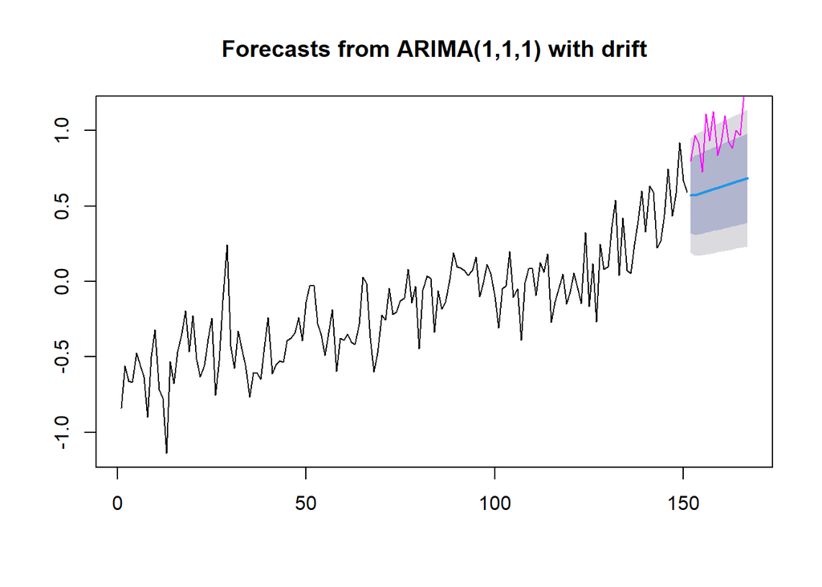

```r
# pot forecast
temp_forecast <- forecast(fit_auto, h = 16)
plot(temp_forecast)

# plot test time series of the period 2001 - 2016
lines(ts(coredata(temp_global_test),
  start = start(temp_forecast$mean)[1],
  frequency = 1
), col = "magenta")
```

Forecast estimates are provided with confidence bounds: 80% confidence limits shaded in darker blue, and 95% in lighter blue. For stationary models (i.e., with $d=0$), forecast intervals converge, for $d>1$, the forecast intervals will continue to grow into the future.

# Trend Analysis: Mann-Kendall Test and Theil-Sen Slope

In time series analysis, detecting whether a monotonic trend exists in a data set is a fundamental task. Unlike regression-based trend detection, non-parametric methods do not require assumptions about the distribution of the data, making them especially suitable for environmental and geoscientific data that may contain outliers, missing values, or non-normal distributions.

Two widely used non-parametric methods for trend analysis are:

1. **Mann-Kendall Test** — a hypothesis test for the presence of a monotonic trend.
2. **Theil-Sen Slope Estimator** — a robust estimator of the magnitude of the trend.

These methods are frequently used in hydrology, climatology, and environmental sciences ([Helsel and Hirsch, 2002](https://pubs.usgs.gov/twri/twri4a3/); [Yue et al., 2002](https://doi.org/10.1002/joc.702)).

### The Mann-Kendall Test

The [Mann-Kendall test](https://en.wikipedia.org/wiki/Kendall_rank_correlation_coefficient) is a non-parametric statistical test used to identify whether a monotonic upward or downward trend exists in a time series. It was originally proposed by [Mann (1945)](https://doi.org/10.2307/1907187) and later refined by [Kendall (1975)](https://en.wikipedia.org/wiki/Kendall_rank_correlation_coefficient).

Given a time series $y_1, y_2, \ldots, y_n$, the Mann-Kendall test statistic $S$ is defined as:

$$S = \sum_{k=1}^{n-1} \sum_{j=k+1}^{n}
\text{sgn}(y_j - y_k)$$

where the sign function is:

$$\text{sgn}(x) =
\begin{cases}
+1 & \text{if } x > 0 \\
0 & \text{if } x = 0 \\
-1 & \text{if } x < 0
\end{cases}$$

Under the null hypothesis $H_0$ (no trend), $S$ is approximately normally distributed with:

- Mean: $E[S] = 0$
- Variance: $\text{Var}(S) = \frac{n(n-1)(2n+5)}{18}$

If there are tied groups, the variance is adjusted:

$$\text{Var}(S) = \frac{n(n-1)(2n+5) -
\sum_{p=1}^{g} t_p(t_p-1)(2t_p+5)}{18}$$

where $g$ is the number of tied groups and $t_p$ is the number of data points in the $p$-th tied group.

The standardized test statistic $Z$ is:

$$Z =
\begin{cases}
\frac{S-1}{\sqrt{\text{Var}(S)}} & \text{if } S > 0 \\
0 & \text{if } S = 0 \\
\frac{S+1}{\sqrt{\text{Var}(S)}} & \text{if } S < 0
\end{cases}$$

A positive $Z$ indicates an upward trend, a negative $Z$ a downward trend. The null hypothesis is rejected if $|Z| > Z_{1-\alpha/2}$.

### The Theil-Sen Slope Estimator

The [Theil-Sen slope estimator](https://en.wikipedia.org/wiki/Theil%E2%80%93Sen_estimator) (also known as Sen’s slope) provides a robust estimate of the magnitude of a trend. It was proposed by Theil (1950) and extended by [Sen (1968)](https://doi.org/10.1080/01621459.1968.10480934).

The Theil-Sen slope $\beta$ is defined as the **median** of all pairwise slopes:

$$\beta = \text{median}\left(\frac{y_j -
y_k}{j - k}\right), \quad \forall \; k < j$$

Key properties:

- It is **robust to outliers** — up to 29.3% of the data can be outliers without significantly affecting the estimate.
- It does **not assume normality** of residuals.
- It provides a **confidence interval** for the slope.

The intercept is typically estimated as:

$$\alpha = \text{median}(y_i) - \beta
\cdot \text{median}(x_i)$$

### Load required libraries

```r
library(dplyr)
library(jsonlite)
library(trend)       # Mann-Kendall test and Sen's slope
library(ggplot2)
library(mblm)        # Median-based linear models (Theil-Sen)
```

### Mann-Kendall Test — Step-by-step implementation

Let’s use the same temperature anomaly data from the previous notebook to perform a Mann-Kendall test and estimate the Theil-Sen slope.

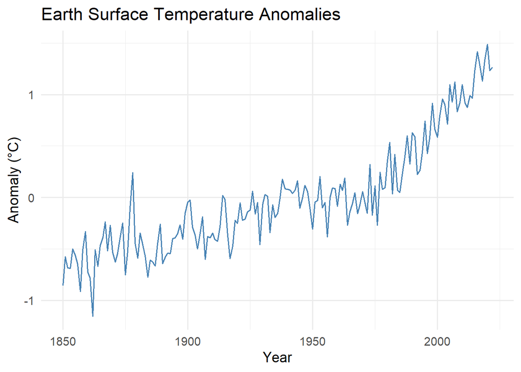

```r
# Load global temperature anomaly data
dataset <- fromJSON(
  "http://userpage.fu-berlin.de/soga/soga-py/300/307000_time_series/t_global.json"
)

t_global <- data.frame(
  Date = as.Date(unlist(dataset$Date), format = "%Y-%m-%d"),
  Monthly_Anomaly_global = sapply(dataset$`Monthly Anomaly_global`, function(x) ifelse(is.null(x), NA, x))
) |>
mutate(Year = as.numeric(format(Date, "%Y")))


# Compute annual mean anomaly
y_df <- aggregate(`Monthly_Anomaly_global` ~ Year, data = t_global, FUN = mean)
y_df <- y_df[y_df$Year >= 1850, ]
colnames(y_df) <- c("Year", "Anomaly")

# Plot the time series
ggplot(y_df, aes(x = Year, y = Anomaly)) +
  geom_line(color = "steelblue") +
  labs(
    title = "Earth Surface Temperature Anomalies",
    x = "Year", y = "Anomaly (°C)"
  ) +
  theme_minimal(base_size = 14)
```

### Using the `trend` package

In practice, we typically use a well-tested library. The [`trend`](https://cran.r-project.org/package=trend) package provides several variants including the original Mann-Kendall test, the seasonal variant, and corrections for autocorrelation.

```r
# Create a time series object
y_ts <- ts(y_df$Anomaly, start = min(y_df$Year), frequency = 1)

# Original Mann-Kendall test
mk_result <- mk.test(y_ts)

cat("Mann-Kendall Test Results (trend package)\n")
```

```
## Mann-Kendall Test Results (trend package)
```

```r
cat(strrep("=", 50), "\n")
cat(sprintf("p-value:        %.6f\n", mk_result$p.value))
```

```
## p-value:        0.000000
```

```r
cat(sprintf("Z statistic:    %.4f\n", mk_result$statistic))
```

```
## Z statistic:    14.2608
```

```r
cat(sprintf("S statistic:    %.0f\n", mk_result$estimates["S"]))
```

```
## S statistic:    10864
```

```r
cat(sprintf("Kendall's tau:  %.4f\n", mk_result$estimates["tau"]))
```

```
## Kendall's tau:  0.7302
```

The `trend` package also provides Sen’s slope estimation alongside the test results — a convenient feature.

### Theil-Sen Slope — Step-by-step implementation

Let us compute the Theil-Sen slope manually, and then compare with the `mblm` package.

```r
theil_sen_slope <- function(x, y) {
  n <- length(x)
  slopes <- c()

  for (k in 1:(n - 1)) {
    for (j in (k + 1):n) {
      if (x[j] != x[k]) {
        slopes <- c(slopes, (y[j] - y[k]) / (x[j] - x[k]))
      }
    }
  }

  slope <- median(slopes)
  intercept <- median(y) - slope * median(x)

  list(slope = slope, intercept = intercept, all_slopes = slopes)
}

result_manual <- theil_sen_slope(y_df$Year, y_df$Anomaly)

cat("Theil-Sen Slope (manual implementation)\n")
```

```
## Theil-Sen Slope (manual implementation)
```

```r
cat(strrep("=", 50), "\n")
cat(sprintf("Slope:     %.6f\n", result_manual$slope))
```

```
## Slope:     0.009166
```

```r
cat(sprintf("Intercept: %.6f\n", result_manual$intercept))
```

```
## Intercept: -17.833428
```

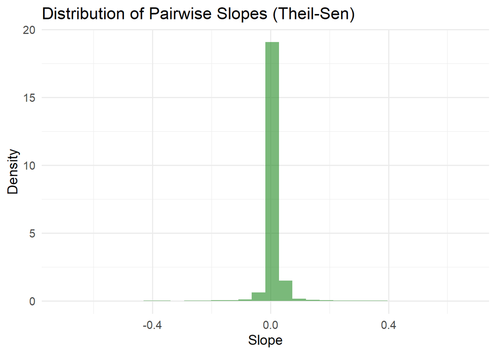

```r
# Plot the distribution of pairwise slopes
ggplot(data.frame(slope = result_manual$all_slopes), aes(x = slope)) +
  geom_histogram(aes(y = after_stat(density)), bins = 30, fill = "forestgreen", alpha = 0.6) +
  labs(
    title = "Distribution of Pairwise Slopes (Theil-Sen)",
    x = "Slope", y = "Density"
  ) +
  theme_minimal(base_size = 14)
```

Now let us compare with the [`mblm`](https://cran.r-project.org/package=mblm) package, which fits a median-based linear model (Theil-Sen estimator) and provides confidence intervals.

```r
# Theil-Sen regression using mblm
ts_model <- mblm(Anomaly ~ Year, data = y_df)
ts_summary <- summary(ts_model)

cat("Theil-Sen Slope (mblm package)\n")
```

```
## Theil-Sen Slope (mblm package)
```

```r
cat(strrep("=", 50), "\n")
cat(sprintf("Slope:              %.6f\n", coef(ts_model)["Year"]))
```

```
## Slope:              0.008578
```

```r
cat(sprintf("Intercept:          %.6f\n", coef(ts_model)["(Intercept)"]))
```

```
## Intercept:          -16.701063
```

```r
# Confidence intervals
ci <- confint(ts_model, level = 0.95)
cat(sprintf("95%% CI lower slope: %.6f\n", ci["Year", 1]))
```

```
## 95% CI lower slope: 0.008098
```

```r
cat(sprintf("95%% CI upper slope: %.6f\n", ci["Year", 2]))
```

```
## 95% CI upper slope: 0.008963
```

Let us visualize the Theil-Sen trend line overlaid on the data.

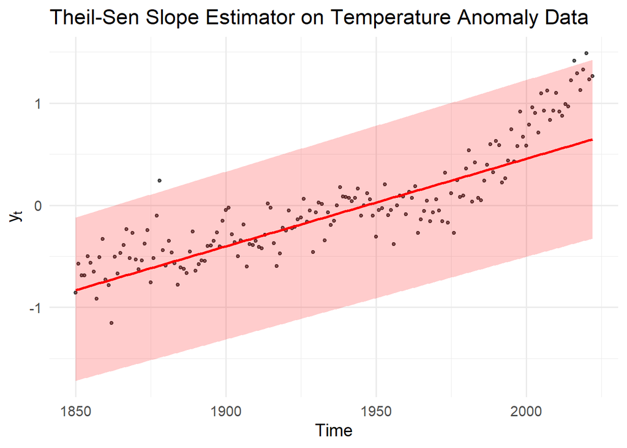

```r
ts_slope <- coef(ts_model)["Year"]
ts_intercept <- coef(ts_model)["(Intercept)"]
ci_slopes <- confint(ts_model, level = 0.95)

y_df$fitted <- ts_intercept + ts_slope * y_df$Year
y_df$ci_lower <- ts_intercept + ci_slopes["Year", 1] * y_df$Year
y_df$ci_upper <- ts_intercept + ci_slopes["Year", 2] * y_df$Year

ggplot(y_df, aes(x = Year, y = Anomaly)) +
  geom_point(size = 1, alpha = 0.6) +
  geom_line(aes(y = fitted), color = "red", linewidth = 1) +
  geom_ribbon(aes(ymin = ci_lower, ymax = ci_upper), alpha = 0.2, fill = "red") +
  labs(
    title = "Theil-Sen Slope Estimator on Temperature Anomaly Data",
    x = "Time", y = expression(y[t])
  ) +
  theme_minimal(base_size = 14)
```

### Comparison: Theil-Sen Slope vs. Ordinary Least Squares (OLS)

A key advantage of the Theil-Sen estimator is its robustness to outliers. Let us demonstrate this by adding artificial outliers to the data.

```r
# Add outliers to a copy of the data
y_outliers <- y_df$Anomaly
outlier_indices <- c(11, 31, 51, 71, 91)  # R is 1-indexed
y_outliers[outlier_indices] <- y_outliers[outlier_indices] + c(8, -10, 12, -9, 11)

# OLS regression (least squares)
ols_fit <- lm(Anomaly ~ Year, data = y_df)
ols_fit_outlier <- lm(y_outliers ~ y_df$Year)

# Theil-Sen slope
ts_fit <- mblm(Anomaly ~ Year, data = y_df, repeated = FALSE)

y_df_outlier <- data.frame(Year = y_df$Year, Anomaly = y_outliers)
ts_fit_outlier <- mblm(Anomaly ~ Year, data = y_df_outlier, repeated = FALSE)

cat("Comparison with outliers\n")
```

```
## Comparison with outliers
```

```r
cat(strrep("=", 50), "\n")
cat(sprintf(
  "OLS slope:        %.6f | OLS slope with outliers:       %.6f\n",
  coef(ols_fit)["Year"], coef(ols_fit_outlier)[2]
))
```

```
## OLS slope:        0.009528 | OLS slope with outliers:       0.008851
```

```r
cat(sprintf(
  "Theil-Sen slope:  %.6f | Theil-Sen slope with outliers: %.6f\n",
  coef(ts_fit)["Year"], coef(ts_fit_outlier)["Year"]
))
```

```
## Theil-Sen slope:  0.009166 | Theil-Sen slope with outliers: 0.009170
```

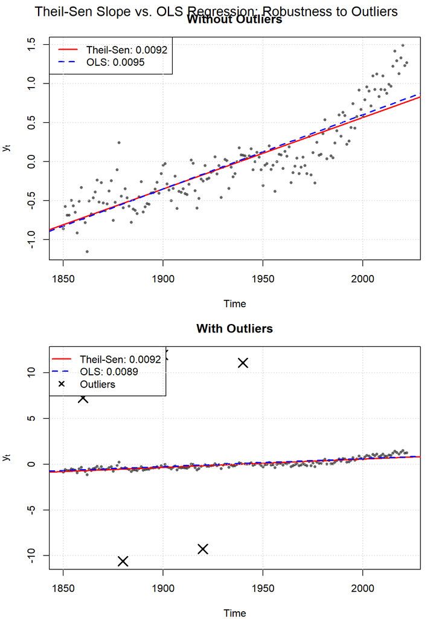

```r
par(mfrow = c(2, 1), mar = c(4, 4, 3, 1))

# Without outliers
plot(y_df$Year, y_df$Anomaly, pch = 16, cex = 0.6, col = rgb(0, 0, 0, 0.6),
     main = "Without Outliers", xlab = "Time", ylab = expression(y[t]))
abline(ts_fit, col = "red", lwd = 2)
abline(ols_fit, col = "blue", lwd = 2, lty = 2)
legend("topleft",
  legend = c(
    sprintf("Theil-Sen: %.4f", coef(ts_fit)["Year"]),
    sprintf("OLS: %.4f", coef(ols_fit)["Year"])
  ),
  col = c("red", "blue"), lwd = 2, lty = c(1, 2)
)
grid()

# With outliers
plot(y_df$Year, y_outliers, pch = 16, cex = 0.6, col = rgb(0, 0, 0, 0.6),
     main = "With Outliers", xlab = "Time", ylab = expression(y[t]))
abline(ts_fit_outlier, col = "red", lwd = 2)
abline(ols_fit_outlier, col = "blue", lwd = 2, lty = 2)
points(y_df$Year[outlier_indices], y_outliers[outlier_indices],
       pch = 4, cex = 2, lwd = 2)
legend("topleft",
  legend = c(
    sprintf("Theil-Sen: %.4f", coef(ts_fit_outlier)["Year"]),
    sprintf("OLS: %.4f", coef(ols_fit_outlier)[2]),
    "Outliers"
  ),
  col = c("red", "blue", "black"), lwd = 2, lty = c(1, 2, NA),
  pch = c(NA, NA, 4)
)
grid()

mtext("Theil-Sen Slope vs. OLS Regression: Robustness to Outliers",
      outer = TRUE, line = -1.5, cex = 1.3)
```

### When to use which test?

The `trend` package offers several variants of the Mann-Kendall test:

| Test Function | Use case |
| --- | --- |
| `mk.test` | Standard Mann-Kendall test for independent data |
| `smk.test` | Seasonal Mann-Kendall test for data with a seasonal component |
| `correlated.season.test` | Seasonal test accounting for cross-correlation between seasons |
| `partial.mk.test` | Partial Mann-Kendall test controlling for a covariate |
| `ww.test` | Wald-Wolfowitz test for randomness |

When autocorrelation is present, the standard Mann-Kendall test may overestimate the significance of the trend. Let us check for autocorrelation and apply the corrected test.

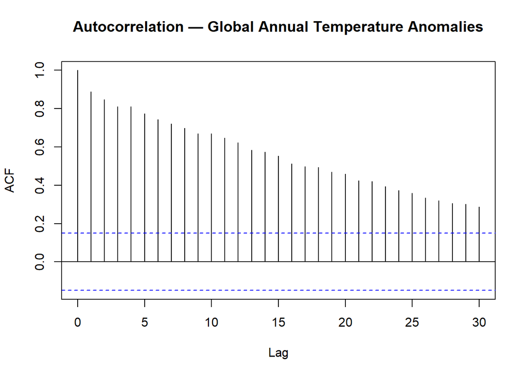

```r
acf(y_ts, lag.max = 30, main = "Autocorrelation — Global Annual Temperature Anomalies")
```

```r
# For autocorrelation-corrected Mann-Kendall, use the trend package's
# modified test or apply pre-whitening

# Using the Yue-Wang modified Mann-Kendall test from the modifiedmk package
# install.packages("modifiedmk")  # if not installed
library(modifiedmk)

mk_modified <- mmky(y_df$Anomaly)

cat("Modified Mann-Kendall Test (Yue-Wang)\n")
```

```
## Modified Mann-Kendall Test (Yue-Wang)
```

```r
cat(strrep("=", 50), "\n")
cat(sprintf("Z statistic:    %.4f\n", mk_modified["Corrected Zc"]))
```

```
## Z statistic:    8.0924
```

```r
cat(sprintf("p-value:        %.6e\n", mk_modified["new P-value"]))
```

```
## p-value:        5.851035e-16
```

```r
cat(sprintf("Kendall's tau:  %.4f\n", mk_modified["Tau"]))
```

```
## Kendall's tau:  0.7302
```

```r
cat(sprintf("Sen's slope:    %.6f °C/year\n", mk_modified["Sen's slope"]))
```

```
## Sen's slope:    0.009166 °C/year
```

```r
cat("\n")
```

```r
cat("Comparison with original test:\n")
```

```
## Comparison with original test:
```

```r
cat(sprintf("  Original p-value:  %.6e\n", mk_result$p.value))
```

```
##   Original p-value:  3.837901e-46
```

```r
cat(sprintf("  Modified p-value:  %.6e\n", mk_modified["new P-value"]))
```

```
##   Modified p-value:  5.851035e-16
```

### Exercises

> **Exercise 1:** Load the Antarctica ice core $CO_2$ data from the URL below. Apply the Mann-Kendall test and Theil-Sen slope. Interpret the results.

> URL: `http://userpage.fu-berlin.de/soga/soga-py/300/307000_time_series/Antartica_Ice_Core.json`

```r
## Your code here ...
```

> **Exercise 2:** Generate a synthetic time series with a **decreasing** trend (e.g., slope = $-0.03$). Apply the Mann-Kendall test and verify that it correctly identifies the direction of the trend. Plot the result with the Theil-Sen trend line.

```r
## Your code here ...
```

> **Exercise 3:** Investigate how sample size affects the power of the Mann-Kendall test. Generate synthetic data with a weak trend (slope = $0.01$) for sample sizes $n = 20, 50, 100, 200, 500$. For each, run the test 1000 times with different random noise, and compute the fraction of times the test correctly rejects $H_0$. Plot the rejection rate as a function of $n$.

```r
## Your code here ...
```

### Summary

- The **Mann-Kendall test** is a non-parametric test for detecting monotonic trends in time series. It does not assume normality and is robust to outliers and missing data.
- The **Theil-Sen slope** provides a robust estimate of the trend magnitude. Unlike OLS, it is resistant to outliers.
- When the data exhibits **autocorrelation**, modified versions of the Mann-Kendall test (e.g., Yue-Wang) should be used to avoid inflated significance.
- Both methods are widely used in environmental and geoscientific applications for trend detection in temperature, precipitation, streamflow, and other variables.

**Citation**

The E-Learning project SOGA-Py was developed at the Department of Earth Sciences by Annette Rudolph, Joachim Krois and Kai Hartmann. You can reach us via mail by soga[at]zedat.fu-berlin.de.

You may use this project freely under the [Creative Commons Attribution-ShareAlike 4.0 International License](http://creativecommons.org/licenses/by-sa/4.0/).

Please cite as follow: *Rudolph, A., Krois, J., Hartmann, K. (2023): Statistics and Geodata Analysis using Python ([SOGA-Py](https://www.geo.fu-berlin.de/soga-py)). Department of Earth Sciences, Freie Universitaet Berlin.*